# 1.3. Skewness and Kurtosis

In addition to measures of location, such as the mean or median, and measures of variation, such as the variance or standard deviation, two more attributes of a frequency distribution of a data set may be of interest to us. These are *skewness and kurtosis*.

## Skewness:

Literally, skewness means ‘lack of symmetry’. We study skewness to have an idea about the shape of the curve which we can draw with the help of the given data. It helps us to determine the nature and extent of the concentration of the observations towards the higher or lower values of the variable. A distribution is said to be skewed if –

- The curve drawn with the help of the given data is not symmetrical but stretched more to one side than to the other
- Mean, Median, and Mode fall at different points, i.e., $Mean \ne Median \ne Mode$
- Quartiles are not equidistant from median.

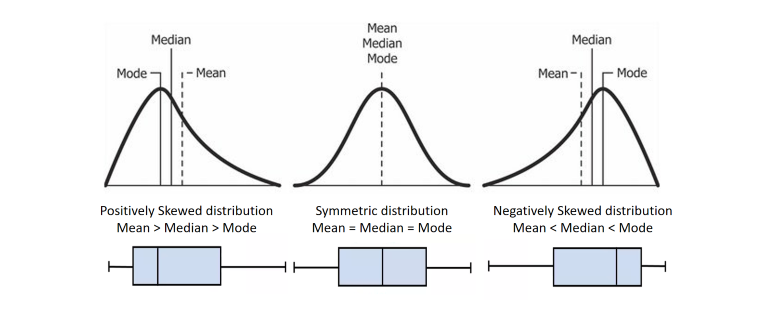

**Positive Skewness** means when the tail on the right side of the distribution is longer or fatter. The mean and median will be greater than the mode i.e., $Mean \gt Median \gt Mode$

**Negative Skewness** is when the tail of the left side of the distribution is longer or fatter than the tail on the right side. The mean and median will be less than the mode i.e., $Mean \lt Median \lt Mode$

$$ Skewness = {1 \over N} \sum\limits_{i = 1}^{N}[{(X_i - \mu)} / {\sigma}]^3 $$

There is also a less complicated formula of finding the skewness which is,

$$ Skewness = \frac {3( Mean - Median )}{Std. Deviation} $$

If skewness = 0, the data are perfectly symmetrical. But a skewness of exactly zero is quite unlikely for real-world data, so how can you interpret the skewness number?

The rule of thumb seems to be:

- If the skewness is between -0.5 and 0.5, the data are fairly symmetrical.
- If the skewness is between -1 and -0.5 (negatively skewed) or between 0.5 and 1 (positively skewed), the data are moderately skewed.
- If the skewness is less than -1(negatively skewed) or greater than 1(positively skewed), the data are highly skewed.

However, skewness can also be easily guessed by observing the shape of Histogram as shown below:

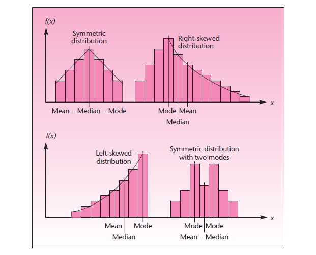

```python
xi = [4, 5, 6, 6, 6, 7, 7, 7, 7, 7, 7, 8, 8, 8, 9, 10]

from statistics import mean, median, mode

m = mean(xi)
md = median(xi)
mo = mode(xi)

print(f"Mean : {m}, Median : {md}, Mode = {mo}")

from scipy.stats import skew

print('\nSkewness: ', skew(xi))
```

```
Mean : 7, Median : 7.0, Mode = 7

Skewness:  0.0
```

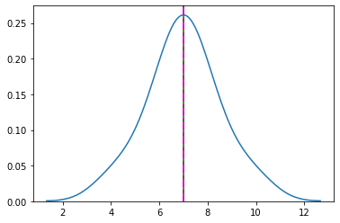

```python
import matplotlib.pyplot as plt
import seaborn as sns

sns.distplot(xi,hist = False)

plt.axvline(m, color='red', linestyle='--')
plt.axvline(md, color='green', linestyle='-')
plt.axvline(mo, color='magenta', linestyle='-.')

plt.show()
```

The mean, the median, and the mode are each 7 for the data i.e.,$Mean = Median = Mode$ . Hence, there is perfect symmetry in distribution.

```python
xi = [4, 5, 6, 6, 6, 7, 7, 7, 7, 8]

from statistics import mean, median, mode

m = mean(xi)
md = median(xi)
mo = mode(xi)

print(f"Mean : {m}, Median : {md}, Mode = {mo}")

from scipy.stats import skew

print('\nSkewness: ', skew(xi))
```

```
Mean : 6.3, Median : 6.5, Mode = 7

Skewness:  -0.613072877535687
```

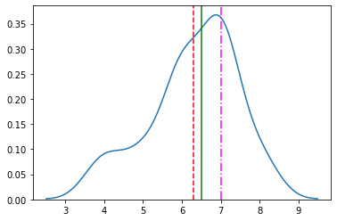

```python
import matplotlib.pyplot as plt
import seaborn as sns

sns.distplot(xi,hist = False)

plt.axvline(m, color='red', linestyle='--')
plt.axvline(md, color='green', linestyle='-')
plt.axvline(mo, color='magenta', linestyle='-.')

plt.show()
```

The mean is 6.3, the median is 6.5, and the mode is 7. Notice that here $Mean \lt Median \lt Mode$. Hence, the distribution is skewed to the left or the distribution is negatively skewed.

```python
xi = [6, 7, 7, 7, 7, 8, 8, 8, 9, 10]

from statistics import mean, median, mode

m = mean(xi)
md = median(xi)
mo = mode(xi)

print(f"Mean : {m}, Median : {md}, Mode = {mo}")

from scipy.stats import skew

print('\nSkewness: ', skew(xi))
```

```
Mean : 7.7, Median : 7.5, Mode = 7

Skewness:  0.613072877535687
```

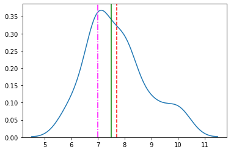

```python
import matplotlib.pyplot as plt
import seaborn as sns

sns.distplot(xi,hist = False)

plt.axvline(m, color='red', linestyle='--')
plt.axvline(md, color='green', linestyle='-')
plt.axvline(mo, color='magenta', linestyle='-.')

plt.show()
```

The mean is 7.7, the median is 7.5, and the mode is seven. Notice that here $Mean \gt Median \gt Mode$. Hence, the distribution is skewed to the right or the distribution is positively skewed.

## Kurtosis:

Two distributions that have the same mean, variance, and skewness could still be significantly different in their shape.

In addition to these measures we should know one more measure which is called as the ‘Convexity of the frequency curve’ or Kurtosis. Kurtosis enables us to have an idea about the ‘flatness or peakedness’ of the frequency curve.

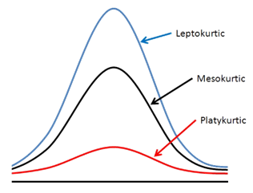

The kurtosis is reported either as relative value to the absolute kurtosis of a normal distribution, a famous distribution about which we will learn later.

**Mesokurtic:** This distribution has kurtosis statistic similar to that of the normal distribution. It means that the extreme values of the distribution are similar to that of a normal distribution characteristic. This definition is used so that the standard normal distribution has a kurtosis of 3.

**Leptokurtic:** Distribution is longer, tails are fatter. Peak is higher and sharper than Mesokurtic, which means that data are heavy-tailed or profusion of outliers. Outliers stretch the horizontal axis of the histogram graph, which makes the bulk of the data appear in a narrow (“skinny”) vertical range, thereby giving the “skinniness” of a leptokurtic distribution.

**Platykurtic:** Distribution is shorter, tails are thinner than the normal distribution. The peak is lower and broader than Mesokurtic, which means that data are light-tailed or lack of outliers. The reason for this is because the extreme values are less than that of the normal distribution.

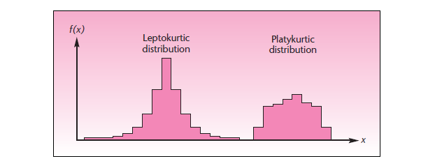

In case of a dataframe, Skewness and Kurtosis cna be obtained by:

```python
import pandas as pd
import numpy as np
```

```python
# Let's build a data set
df = pd.DataFrame([
 { 'name': 'Smushface', 'salary': 12000,'degree': 'BS'} ,
 { 'name': 'Jen', 'salary': 25000,'degree': 'BS' },
 { 'name': 'James', 'salary': 55000,'degree': 'MS' },
 { 'name': 'Ross', 'salary': 35000,'degree': 'MS' },
 { 'name': 'Tyler', 'salary': 25000,'degree': 'BS' },
 { 'name': 'Jacques', 'salary': 15000,'degree': 'BS' },
 { 'name': 'Gates', 'salary': 100000,'degree': 'PhD' },
 { 'name': 'Peter', 'salary': 30000,'degree': 'MS' },
 { 'name': 'Adam', 'salary': 25000,'degree': 'MS' },
 { 'name': 'Brian', 'salary': 20000,'degree': 'BS' }
])
df
```

|  | name | salary | degree |
| --- | --- | --- | --- |
| 0 | Smushface | 12000 | BS |
| 1 | Jen | 25000 | BS |
| 2 | James | 55000 | MS |
| 3 | Ross | 35000 | MS |
| 4 | Tyler | 25000 | BS |
| 5 | Jacques | 15000 | BS |
| 6 | Gates | 100000 | PhD |
| 7 | Peter | 30000 | MS |
| 8 | Adam | 25000 | MS |
| 9 | Brian | 20000 | BS |

```python
df['salary'].skew()
```

```
2.131161813527506
```

```python
df['salary'].kurtosis()
```

```
4.872700466158332
```

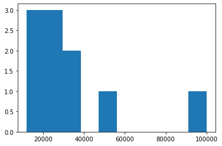

```python
import matplotlib.pyplot as plt
%matplotlib inline

plt.hist(x='salary',data=df)
plt.show()
```

[figure not shown]

```python
import matplotlib.pyplot as plt
import seaborn as sns

sns.distplot(df['salary'],hist = False)
plt.xlabel('Salary')
plt.show()
```